# Name: Tanner Woods

## Imports

```python
import datetime
import numpy as np
import pandas as pd
import yfinance as yf
import seaborn as sns
import itertools as it
import matplotlib.pyplot as plt
import statsmodels.formula.api as smf

from sklearn.model_selection import train_test_split as tts
```

# Question 1

## Question 1A

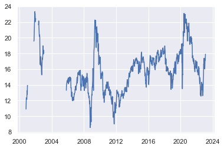

```python
HW_data = pd.read_excel('forwardSector.xlsx', parse_dates = True, index_col = 0)
Material_Sector = pd.DataFrame(HW_data.iloc[:,0])

## Checking for discontinuities in select series and cutting them from series
plt.figure()
plt.plot(Material_Sector)
plt.show()

Materials_Cont = Material_Sector[Material_Sector.index >= '2006-01-01']
```

```
[*********************100%***********************]  1 of 1 completed
```

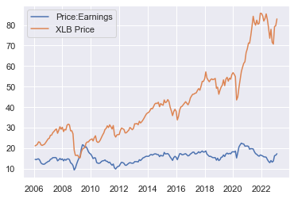

```python
## Pulling corresponding materials ETF price series
sector = "XLB"
XLB = yf.download(sector)[["Adj Close"]].copy()
XLB_cont = XLB[XLB.index >= '2006-01-01']

Data = Materials_Cont.merge(XLB_cont, left_index = True, right_index = True)[::-1]
Data = Data.resample('M').mean()
Data.columns = ['Sector PE','Adj Close']
Data["Returns"] = np.log(Data["Adj Close"]).diff()

## Visualizing PE and price series
plt.figure()
plt.plot(Data.iloc[:,0], label = 'Price:Earnings')
plt.plot(Data.iloc[:,1], label = 'XLB Price')
plt.legend()
plt.show()
```

## Question 1B

```python
def Systematic_Train_Test (data, train_ratio):
    train_size = int(len(data) * train_ratio)
    train, test = data[0:train_size], data[train_size:]
    return train, test

X_Train, X_Test = Systematic_Train_Test(Data, train_ratio = 0.8)

# Dec. candidate values for hyperparameter grid
k = np.linspace(.01, .99, 10)
z = np.linspace(.01, 3, 10)
w = np.arange(5, 30, 5)
h = 8

grid = np.array(np.meshgrid(k,z,w,h)).T.reshape(-1,4)

Data.rename(columns={"S5MATR Index (R1)": "Sector PE"})

storage = pd.DataFrame(columns = ["k", "z", "w", "h", "profits"])
df_copy = Data.copy()

for n in range(len(grid)):
    # Each loop we pull out the values for a new set of hyperparamters from the grid
    k,z,w,h= grid[n]

    # We fit a filter and CI using the next set of parameters
    df_copy["Filter"] = df_copy["Sector PE"].ewm(alpha = k, adjust = False).mean()
    df_copy["Filter Error"] = df_copy["Sector PE"] -df_copy["Filter"]
    df_copy["std"] = df_copy["Filter Error"].rolling(int(w)).std()
    df_copy["Upper"] = df_copy["Filter"] + z*df_copy["std"]
    df_copy["Lower"] = df_copy["Filter"] - z*df_copy["std"]
    df_copy["test"] = np.where(df_copy["Filter Error"].abs()>z*df_copy["std"], 1, 0)*np.sign(df_copy["Filter Error"])

    # create vectors where we can store information on signals and when the change is first signalled
    df_copy["test2"] = 0
    df_copy["signal"] = 0

    for j in df_copy.index:
        # if there is a change in the signal, we want to take a position for teh next h periods
        if (df_copy.loc[j, "test"] == 1) &  (df_copy.shift().loc[j, "test"] != 1):
            df_copy.loc[j:j+datetime.timedelta(h), "signal"] = 1
            df_copy.loc[j, "test2"] = 1
        elif (df_copy.loc[j, "test"] == -1) &  (df_copy.shift().loc[j, "test"] != -1):
            df_copy.loc[j:j+datetime.timedelta(h), "signal"] =  -1
            df_copy.loc[j, "test2"] = -1

    # calculate metric
    df_copy["cumulative_returns"] = np.exp((df_copy["signal"].shift()*df_copy.Returns).cumsum())-1

    # store the results
    storage = storage.append({"k":k, "z":z, "w":w, "h":h,
                "profits":df_copy["cumulative_returns"][-1]}, ignore_index = True)
    # print so I can track progress of loop (can take a few minutes)
    # print(n)
```

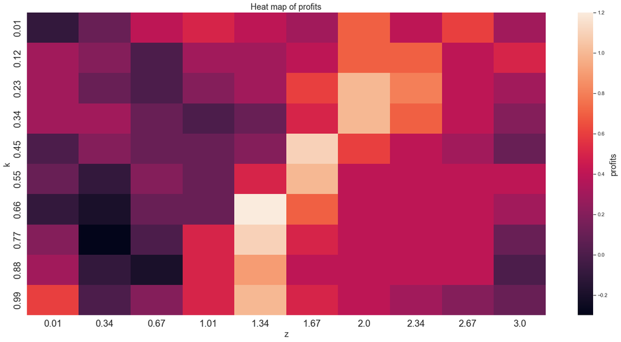

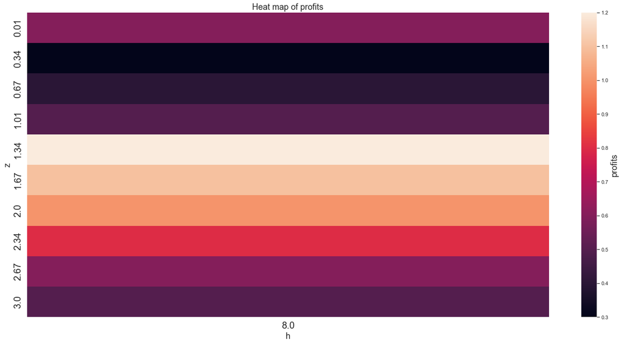

```python
def heatmap(x, y, metric, values):

    # specify the columns I will be pulling from the results
    p2p = values[[x, y, metric]]

    # If p > 2, we need to group
    heat = np.round(p2p.groupby([x,y]).max(),1)
    heat = heat.unstack()[metric]

    # round labels
    heat.index = np.round(heat.index,2)
    heat.columns = np.round(heat.columns,2)

    # make plot
    f, ax = plt.subplots(figsize=(25, 12))
    ax = sns.heatmap(heat, fmt='.1g')
    ax.set_title("Heat map of "+ metric,size = 18)
    ax.tick_params(axis='both', which='major', labelsize=20)
    ax.set_xlabel(y, size = 18)
    ax.set_ylabel(x, size = 18)
    ax.collections[0].colorbar.set_label(metric, size = 18)
    sns.set(font_scale=1)
    plt.show()

storage = storage.sort_values(by = "profits").reset_index(drop = True)
heatmap("k", "z","profits", storage)
heatmap("z", "h","profits", storage)
k,z,w,h,p = storage.iloc[-1]
```

```python
df_copy["Filter"] = df_copy["Sector PE"].ewm(alpha = k, adjust = False).mean()
df_copy["Filter Error"] = df_copy["Sector PE"] -df_copy["Filter"]
df_copy["std"] = df_copy["Filter Error"].rolling(int(w)).std()
df_copy["Upper"] = df_copy["Filter"] + z*df_copy["std"]
df_copy["Lower"] = df_copy["Filter"] - z*df_copy["std"]

df_copy["test"] = np.where(df_copy["Filter Error"].abs()>z*df_copy["std"], 1, 0)*np.sign(df_copy["Filter Error"])

df_copy["test2"] = 0
df_copy["signal"] = 0
for j in df_copy.index:
    if (df_copy.loc[j, "test"] == 1) &  (df_copy.shift().loc[j, "test"] != 1):
        df_copy.loc[j:j+datetime.timedelta(h), "signal"] = 1
        df_copy.loc[j, "test2"] = 1
    elif (df_copy.loc[j, "test"] == -1) &  (df_copy.shift().loc[j, "test"] != -1):
        df_copy.loc[j:j+datetime.timedelta(h), "signal"] =  -1
        df_copy.loc[j, "test2"] = -1
df_copy["cumulative_returns"] = np.exp((df_copy["signal"].shift()*df_copy.Returns).cumsum())-1
df_copy["strat_returns"] = df_copy["signal"].shift()*df_copy.Returns
```

Final hyperparams. are approximately as follows:

k* = 0.663333

z* = 1.338889

w* = 5

h* = h = 8

Selected on the basis of most optimal performance by final profit via CV above; this is save for the set value of 8 for the holding period.

## Question 1C

```python
OneYear_TRYC = pd.read_csv('1-year-treasury-rate-yield-chart.csv', parse_dates = True, index_col = 0)
OneYear_TRYC = OneYear_TRYC[OneYear_TRYC.index >= '2006-01-01'].resample('1Y').mean()
```

```python
P = 1000
A = (((df_copy["cumulative_returns"]/P)+1)*P)[-1]
y = len(df_copy.index)/12

## Tot. RoR = ...
z = (A-P)/P
print(f'The total rate of return on our strategy is approx. {np.round(z, 5)}, or {np.round(z*100, 3)}%.')
print('\n')

## Ann. RoR = (End Value / Start Value)^(1/(79/12)) - 1
ARS = ((A/P)**(1/y)-1)
print(f'The annualized rate of return of our strategy is approx {np.round(ARS, 5)}, or {np.round(ARS*100, 3)}%.')
print('\n')

## RoR on Held Positions
## May need to pick diff sector bc no test2 == -1
## Start_Hold = df_copy["cumulative_returns"][df_copy['test2'] == 1]
## End_Hold = df_copy["cumulative_returns"][df_copy['test2'] == -1]
RoR_H = (((df_copy["cumulative_returns"][df_copy['test2'] == 1]/100)+1)*1000 - 1000)/1000
print(f'The rate of return on held positions is approx. {np.round(RoR_H[-1], 5)}, or {np.round(RoR_H[-1]*100, 3)}%.')
print('\n')

## Sharpe Ratio = E[R_a - R_b]/(StDev_a)
R_a = df_copy["cumulative_returns"].resample('1Y').mean()
R_b = OneYear_TRYC.iloc[:,0]
StDev_a = np.std(df_copy["cumulative_returns"].resample('1Y').mean())
Sharpe_R = np.mean(R_a - R_b)/StDev_a
print(f'The Sharpe Ratio of our strategy is {Sharpe_R}')
print('I am definitely not going into trading.')
print('\n')

## Gini coefficient = ...
def GINI_COEF(returns):
    # get the number of periods -> will allow us to calculate the areas
    periods = len(returns)

    # sort values and sum to calculate the lorenz curve
    LorenzCurve = np.cumsum(returns.sort_values(by = "Returns"))
    # start from 0
    LorenzCurve = pd.DataFrame({ 'Returns': [0]}).append(LorenzCurve)
    Line = LorenzCurve.copy()
    # Form the line that encompasses A and B
    Line["Returns"] = np.arange(0,1+1/periods, 1/periods)*max(LorenzCurve["Returns"])

    # calculate the area of A+B
    UpArea = 0
    for i in range(1,len(returns)):
        UpArea = UpArea + ((Line.iloc[i,:] - LorenzCurve.iloc[i,:] + Line.iloc[i-1,:] - LorenzCurve.iloc[i-1,:]) / 2)
    # calculate the area of A+B+C
    if min(LorenzCurve["Returns"]) < 0:
        AllArea = (np.abs(min(LorenzCurve["Returns"])) * periods) + ((max(LorenzCurve["Returns"]) * periods)/2)
    else:
        AllArea = ((max(LorenzCurve["Returns"]) * periods)/2)
    gini = UpArea / AllArea
    return(gini[0])

Gini = GINI_COEF(df_copy[["Returns"]])
print(f'The Gini coefficient of the strategy is approx. {np.round(Gini, 5)}')
```

```
The total rate of return on our strategy is approx. 0.00117, or 0.117%.


The annualized rate of return of our strategy is approx 7e-05, or 0.007%.


The rate of return on held positions is approx. 0.0116, or 1.16%.


The Sharpe Ratio of our strategy is -1.422876633510169
I am definitely not going into trading.


The Gini coefficient of the strategy is approx. 0.69401
```

```python
df_copy[["Returns"]]
```

| Date | Returns |
| --- | --- |
| 2006-01-31 | NaN |
| 2006-02-28 | 0.013412 |
| 2006-03-31 | 0.021630 |
| 2006-04-30 | 0.052078 |
| 2006-05-31 | -0.007775 |
| ... | ... |
| 2022-09-30 | -0.084412 |
| 2022-10-31 | -0.012857 |
| 2022-11-30 | 0.113814 |
| 2022-12-31 | 0.005612 |
| 2023-01-31 | 0.040671 |

205 rows × 1 columns

# Question 2

## Question 2A

Where YTM = (FaceValue/PresentValue)^(1/n) - 1, for a semi-annual 10-year bond:

YTM = (1000/983.125)^(1/20) - 1 = 0.0008513 (0.08513%)

## Question 2B

Where YTM = (FaceValue/PresentValue)^(1/n) - 1, for an annualized 10-year bond:

YTM = (1000/983.125)^(1/10) - 1 = 0.001703 (0.1703%)

# Question 3

```python
HW_data = pd.read_csv('Hw3_Interest_Rates.csv', parse_dates = True, index_col = 0)
HW_data = HW_data.iloc[:,0:2]
#HW_data['USD > EUR'] = np.where(HW_data['United States'] > HW_data['Euro Area'], 1, -1)
#HW_data['Returns'] = 0
HW_data.head()
df = HW_data
```

```python
profits = np.array([])
maxI = df.idxmax(axis = 1)
minI = df.idxmin(axis = 1)

for j in range(len(df)-1):

    # identify the country with the highest (long)
    # and lowest (short) yield
    long = maxI[j]
    short = minI[j]

    # get the exchange rate at t0 and t+1
    # for the short
    sts0 = df[short][j]
    sts1 = df[short][j+1]

    # get the monthly interest rate
    # for the short
    si = df[short][j]

    # calculate the amount owed
    owed = P*sts0*si/sts1

    # get the exchange rate at t0 and t+1
    # for the long
    stl0 = df[long][j]
    stl1 = df[long][j+1]

    # get the monthly interest rate for the long
    li = df[long][j]

    # calculate the ending balance
    balance = P*stl0*li/stl1

    # calculate the profit
    profit = balance - owed

    # store the profits
    profits = np.append(profits, profit)

profits = pd.DataFrame(profits, index = df.index[:-1], columns = ["Profit"])
```

```python
OneYear_TRYC = pd.read_csv('1-year-treasury-rate-yield-chart.csv', parse_dates = True, index_col = 0)
OneYear_TRYC = OneYear_TRYC[OneYear_TRYC.index > '2000-02-29'].resample('1M').mean()
OneYear_TRYC = OneYear_TRYC[OneYear_TRYC.index < '2022-12-01']
rfr = pd.DataFrame(OneYear_TRYC.values)
rfr.columns = ['value']
rfr.index = OneYear_TRYC.index
sp500 = yf.download("^GSPC")[["Adj Close"]]
```

```
[*********************100%***********************]  1 of 1 completed
```

```python
df['Returns'] = profits.diff()/profits
df["cumulative_returns"] = df['Returns'].cumsum()
df = df[df.index < '2023-01-01']
A = (((df["cumulative_returns"]/P)+1)*P)[-1]

## Tot. RoR = ...
z = (A-P)/P
print(f'The total rate of return on our strategy is approx. {np.round(z, 5)}, or {np.round(z*100, 3)}%.')
print('\n')

## Ann. RoR = (End Value / Start Value)^(1/(79/12)) - 1
ARS = ((A/P)**(1/y)-1)
print(f'The annualized rate of return of our strategy is approx {np.round(ARS, 5)}, or {np.round(ARS*100, 3)}%.')
print('\n')

## Alpha and Beta
sp500 = sp500[sp500.index < '2022-12-01'].resample('1M').mean()
sp500 = sp500.rolling(1,axis=1).sum().pct_change()
sp500 = sp500[sp500.index > '2000-02-29']

#profits = profits.rolling(1,axis=1).sum().pct_change()
profits = profits[profits.index > '2000-02-29']
profits = profits[profits.index < '2022-12-01']

rfr['Strat_Excess'] = profits['Profit'].values - rfr['value'].values
rfr['Mrket_Excess'] = sp500["Adj Close"].values - rfr['value'].values

regr = smf.ols('Strat_Excess ~ Mrket_Excess', data = rfr).fit()
print(f'The alpha of our strategy is {regr.params[0]}')
print(f'The beta of our strategy is {regr.params[1]}')
print('\n')

## Sharpe
R_a = df["cumulative_returns"].resample('1Y').mean()
OneYear_TRYC = OneYear_TRYC.resample('1M').mean()
R_b = OneYear_TRYC.iloc[:,0]
StDev_a = np.std(df["cumulative_returns"].resample('1Y').mean())
Sharpe_R = np.mean(R_a - R_b)/StDev_a
print(f'The Sharpe Ratio of our strategy is {Sharpe_R}')
print('\n')

##
Gini = GINI_COEF(df[['Returns']].dropna())
print(f'The Gini coefficient of the strategy is approx. {np.round(Gini, 5)}')
```

```
The total rate of return on our strategy is approx. 0.00621, or 0.621%.


The annualized rate of return of our strategy is approx 0.00036, or 0.036%.


The alpha of our strategy is 0.5377664473160303
The beta of our strategy is 0.7878010676934464


The Sharpe Ratio of our strategy is 0.30102461767195865


The Gini coefficient of the strategy is approx. 0.90516
```

# Question 4

## Question 4A

If investors believe that the Fed is merely posing in its stance on inflation, then they will continue to bet that the upcoming rate hikes are just wordplay to ease fears on inflation. Therefore, investors will continue to stoke the economy — thereby increasing inflationary pressures — and increase the challenge that the Fed faces in lowering inflation. Furthermore, this runs the risk of a rug-pull on investors who charge ahead: if the drop in rates does not occur as predicted, then this could decrease confidence in the economy and potentially spark a new round of instability; an unsteady economy generally entails some form of loss suffered by those with money in it.

## Question 4B

Currently, the stock market is experiencing relative instability with little-to-no growth: the DOW Jones has seen a general adjustment of only approx. -1.47% over the last year (approx. -1.00% YTD).

# Question 5

I believe the primary reason for increasing stock prices despite all rationality is simple: instability brings with it a fantastic opportunity to make money, as long as you aren't the one holding the bag at the end. Another substantial secondary reason can be found behind the enormous quantity of money released into the economy throughout COVID. I believe that investors see the government rushing to prevent a total economic collapse during the early pandemic, then extrapolate it to any future crisis in the market. Of course, this isn't incorrect if the next crisis is as big and bold as COVID. However, such events are hallmarks of a generation and rarely (and hopefully) not repeated at such large scales.